# S&P 500 — Market Risk Analysis

Historical VaR · Expected Shortfall · IMA Charge · Basel Backtesting

Karol Kudłacik

> **Objective:** Build a complete market risk framework for the S&P 500 — from raw price data to regulatory capital metrics — covering Historical VaR, Expected Shortfall, IMA stress-period identification, and Basel III backtesting with traffic-light classification.

# 1 Setup

```r
library(zoo)
```

# 2 Data Loading & Preparation

**Data source:** Daily S&P 500 OHLC prices from `^spx_d.csv`.  
**Sample period:** 1995-01-01 onwards (≈ 30 years of trading days).  
Only `Date`, `Open`, and `Close` columns are retained; incomplete rows are dropped.

```r
sp500_data       <- read.csv("^spx_d.csv")
sp500_data$Date  <- as.Date(sp500_data$Date)
sp500_data       <- sp500_data[order(sp500_data$Date), ]

# Filter from 1995-01-01
cutoff_date      <- as.Date("1995-01-01")
sp500_filtered   <- sp500_data[sp500_data$Date >= cutoff_date, c("Date", "Open", "Close")]
sp500_filtered   <- sp500_filtered[complete.cases(sp500_filtered), ]

close_vec        <- sp500_filtered$Close
dates_vec        <- sp500_filtered$Date

cat("Observations after 1995-01-01:", nrow(sp500_filtered), "\n")
```

```
## Observations after 1995-01-01: 7857
```

```r
cat("Date range:", format(min(dates_vec)), "to", format(max(dates_vec)), "\n\n")
```

```
## Date range: 1995-01-03 to 2026-03-23
```

# 3 Return Computation

## 3.1 Simple Returns — 1-Day and 10-Day

The simple (arithmetic) return over a holding period $h$ is:

$$r_t^{(h)} = \frac{P_t -
P_{t-h}}{P_{t-h}}$$

where $h = 1$ for daily and $h = 10$ for the ten-trading-day Basel horizon.

```r
#   1-day:  r_t  =  (P_t  - P_{t-1})  / P_{t-1}
#   10-day: r_t  =  (P_t  - P_{t-10}) / P_{t-10}
returns_1d  <- diff(close_vec, lag = 1)  / head(close_vec, -1)
returns_10d <- diff(close_vec, lag = 10) / head(close_vec, -10)

# Align dates (we lose the first 1 / first 10 observations respectively)
dates_1d    <- dates_vec[-1]
dates_10d   <- dates_vec[-(1:10)]

cat("1-day  return observations:", length(returns_1d),  "\n")
```

```
## 1-day  return observations: 7856
```

```r
cat("10-day return observations:", length(returns_10d), "\n\n")
```

```
## 10-day return observations: 7847
```

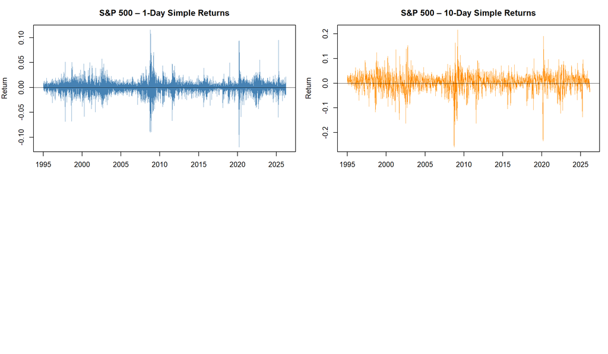

```r
par(mfrow = c(2, 2), mar = c(3, 4, 3, 1))

# ── Panel 1 : 1-day returns ──────────────────────────────────────────────────
plot(dates_1d, returns_1d,
     type = "l", col = "steelblue", lwd = 0.7,
     main = "S&P 500 – 1-Day Simple Returns",
     xlab = "", ylab = "Return", xaxt = "n")
axis.Date(1, at = seq(min(dates_1d), max(dates_1d), by = "5 years"), format = "%Y")
abline(h = 0, col = "black", lwd = 0.8)

# ── Panel 2 : 10-day returns ─────────────────────────────────────────────────
plot(dates_10d, returns_10d,
     type = "l", col = "darkorange", lwd = 0.7,
     main = "S&P 500 – 10-Day Simple Returns",
     xlab = "", ylab = "Return", xaxt = "n")
axis.Date(1, at = seq(min(dates_10d), max(dates_10d), by = "5 years"), format = "%Y")
abline(h = 0, col = "black", lwd = 0.8)

par(mfrow = c(1, 1))
```

# 4 Historical Value-at-Risk (VaR)

## 4.1 Methodology

**Parameters**

| Parameter | Value |
| --- | --- |
| Lookback window | 252 trading days |
| Confidence level | 99% |
| Interpolation | Linear (equivalent to `quantile` type 6) |

**Interpolation formula:**
Position $h = (n+1) \times p = 253 \times 0.01 = 2.53$
$$\text{VaR}_t = -\left[r_{(2)} + 0.53 \cdot
\left(r_{(3)} - r_{(2)}\right)\right]$$
where $r_{(k)}$ denotes the $k$-th order statistic (ascending).

## 4.2 Helper Function

```r
window <- 252

hist_VaR <- function(returns_vec, window = 252, conf = 0.99) {
  n      <- length(returns_vec)
  p      <- 1 - conf                          # 0.01 for 99% VaR
  VaR    <- rep(NA_real_, n)

  for (t in (window + 1):n) {
    window_returns <- returns_vec[(t - window):(t - 1)]   # 252 past returns
    sorted         <- sort(window_returns)                 # ascending (worst first)

    # Linear interpolation between 2nd and 3rd worst
    h   <- (window + 1) * p                  # = 253 × 0.01 = 2.53
    lo  <- floor(h)                           # = 2
    hi  <- lo + 1                             # = 3
    frac <- h - lo                            # = 0.53

    VaR[t] <- -(sorted[lo] + frac * (sorted[hi] - sorted[lo]))
    # negative sign → convert loss (negative return) to positive VaR
  }
  return(VaR)
}
```

## 4.3 Rolling VaR Calculation

```r
VaR_1d  <- hist_VaR(returns_1d,  window = 252, conf = 0.99)
VaR_10d <- hist_VaR(returns_10d, window = 252, conf = 0.99)

# Remove the burn-in NAs for summary
VaR_1d_clean  <- na.omit(VaR_1d)
VaR_10d_clean <- na.omit(VaR_10d)

cat("=== 1-Day Historical VaR (99%) ===\n")
```

```
## === 1-Day Historical VaR (99%) ===
```

```r
print(summary(VaR_1d_clean))
```

```
##    Min. 1st Qu.  Median    Mean 3rd Qu.    Max.
## 0.01378 0.02194 0.02952 0.03225 0.03620 0.08864
```

```r
cat("\n=== 10-Day Historical VaR (99%) ===\n")
```

```
##
## === 10-Day Historical VaR (99%) ===
```

```r
print(summary(VaR_10d_clean))
```

```
##    Min. 1st Qu.  Median    Mean 3rd Qu.    Max.
## 0.01877 0.04922 0.07310 0.08403 0.09970 0.23191
```

## 4.4 Returns vs. Rolling VaR — Charts

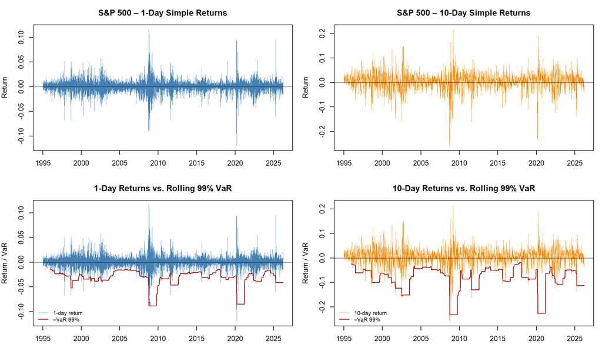

```r
par(mfrow = c(2, 2), mar = c(3, 4, 3, 1))

# ── Panel 1 : 1-day returns ──────────────────────────────────────────────────
plot(dates_1d, returns_1d,
     type = "l", col = "steelblue", lwd = 0.7,
     main = "S&P 500 – 1-Day Simple Returns",
     xlab = "", ylab = "Return", xaxt = "n")
axis.Date(1, at = seq(min(dates_1d), max(dates_1d), by = "5 years"), format = "%Y")
abline(h = 0, col = "black", lwd = 0.8)

# ── Panel 2 : 10-day returns ─────────────────────────────────────────────────
plot(dates_10d, returns_10d,
     type = "l", col = "darkorange", lwd = 0.7,
     main = "S&P 500 – 10-Day Simple Returns",
     xlab = "", ylab = "Return", xaxt = "n")
axis.Date(1, at = seq(min(dates_10d), max(dates_10d), by = "5 years"), format = "%Y")
abline(h = 0, col = "black", lwd = 0.8)

# ── Panel 3 : 1-day returns + rolling VaR ────────────────────────────────────
plot(dates_1d, returns_1d,
     type = "l", col = "steelblue", lwd = 0.7,
     main = "1-Day Returns vs. Rolling 99% VaR",
     xlab = "", ylab = "Return / VaR", xaxt = "n")
axis.Date(1, at = seq(min(dates_1d), max(dates_1d), by = "5 years"), format = "%Y")
lines(dates_1d, -VaR_1d, col = "firebrick", lwd = 1.5)   # VaR as loss threshold
abline(h = 0, col = "black", lwd = 0.8)
legend("bottomleft", legend = c("1-day return", "–VaR 99%"),
       col = c("steelblue", "firebrick"), lwd = c(0.7, 1.5), bty = "n", cex = 0.8)

# ── Panel 4 : 10-day returns + rolling VaR ───────────────────────────────────
plot(dates_10d, returns_10d,
     type = "l", col = "darkorange", lwd = 0.7,
     main = "10-Day Returns vs. Rolling 99% VaR",
     xlab = "", ylab = "Return / VaR", xaxt = "n")
axis.Date(1, at = seq(min(dates_10d), max(dates_10d), by = "5 years"), format = "%Y")
lines(dates_10d, -VaR_10d, col = "firebrick", lwd = 1.5)
abline(h = 0, col = "black", lwd = 0.8)
legend("bottomleft", legend = c("10-day return", "–VaR 99%"),
       col = c("darkorange", "firebrick"), lwd = c(0.7, 1.5), bty = "n", cex = 0.8)
```

```r
par(mfrow = c(1, 1))
```

## 4.5 VaR Breach Analysis

A **breach** occurs when the realised loss on day $t$ exceeds the VaR estimate:
$$-r_t > \widehat{\text{VaR}}_t$$
At 99% confidence the expected breach rate is **~1%** of trading days.

```r
# A breach occurs when the actual return is WORSE than -VaR
breaches_1d  <- sum(-returns_1d  > VaR_1d,  na.rm = TRUE)
breaches_10d <- sum(-returns_10d > VaR_10d, na.rm = TRUE)

total_1d  <- sum(!is.na(VaR_1d))
total_10d <- sum(!is.na(VaR_10d))

cat("\n=== VaR Breach Analysis ===\n")
```

```
##
## === VaR Breach Analysis ===
```

```r
cat(sprintf("1-Day  VaR breaches: %d / %d  (%.2f%%)  | expected ~1%%\n",
            breaches_1d,  total_1d,  100 * breaches_1d  / total_1d))
```

```
## 1-Day  VaR breaches: 97 / 7604  (1.28%)  | expected ~1%
```

```r
cat(sprintf("10-Day VaR breaches: %d / %d  (%.2f%%)  | expected ~1%%\n",
            breaches_10d, total_10d, 100 * breaches_10d / total_10d))
```

```
## 10-Day VaR breaches: 127 / 7595  (1.67%)  | expected ~1%
```

# 5 Expected Shortfall (ES)

## 5.1 Methodology

**Expected Shortfall** (also called CVaR or ES) answers the question:

> *“Given that we are in the worst 2.5% of days, what is the average loss?”*

**Parameters**

| Parameter | Value |
| --- | --- |
| Confidence level | 97.5% |
| Tail probability $p$ | 2.5% |
| Lookback window | 252 trading days |
| Tail observations | $252 \times 0.025 = 6.3$ |

**Weighted average formula:**
$$\text{ES}_t = -\frac{1}{6.3}\left[\sum_{k=1}^{6}
r_{(k)} + 0.3 \cdot r_{(7)}\right]$$
where $r_{(k)}$ are sorted ascending (worst first).

## 5.2 Helper Function

```r
hist_ES <- function(returns_vec, window = 252, conf = 0.975) {
  n    <- length(returns_vec)
  p    <- 1 - conf                        # 0.025 tail probability
  ES   <- rep(NA_real_, n)

  # Number of observations in the tail (fractional)
  tail_n    <- window * p                 # 252 × 0.025 = 6.3
  tail_full <- floor(tail_n)             # 6   – fully included observations
  tail_frac <- tail_n - tail_full        # 0.3 – partial weight on 7th obs

  for (t in (window + 1):n) {
    window_returns <- returns_vec[(t - window):(t - 1)]
    sorted         <- sort(window_returns)   # ascending: worst returns first

    # Weighted sum: 6 full worst + 0.3 × 7th worst
    tail_sum <- sum(sorted[1:tail_full]) + tail_frac * sorted[tail_full + 1]

    # Divide by total weight (6.3) and flip sign → positive loss number
    ES[t] <- -tail_sum / tail_n
  }
  return(ES)
}
```

## 5.3 Rolling ES Calculation

```r
# ── STEP 1 – Calculate rolling ES for 1-day and 10-day returns ───────────────
ES_1d  <- hist_ES(returns_1d,  window = 252, conf = 0.975)
ES_10d <- hist_ES(returns_10d, window = 252, conf = 0.975)

ES_1d_clean  <- na.omit(ES_1d)
ES_10d_clean <- na.omit(ES_10d)

cat("=== 1-Day Expected Shortfall (97.5%) ===\n")
```

```
## === 1-Day Expected Shortfall (97.5%) ===
```

```r
print(summary(ES_1d_clean))
```

```
##    Min. 1st Qu.  Median    Mean 3rd Qu.    Max.
## 0.01201 0.02009 0.02843 0.03022 0.03529 0.07785
```

```r
cat("\n=== 10-Day Expected Shortfall (97.5%) ===\n")
```

```
##
## === 10-Day Expected Shortfall (97.5%) ===
```

```r
print(summary(ES_10d_clean))
```

```
##    Min. 1st Qu.  Median    Mean 3rd Qu.    Max.
## 0.01711 0.04703 0.06976 0.07822 0.09462 0.20468
```

## 5.4 Returns, VaR and ES — Combined Charts

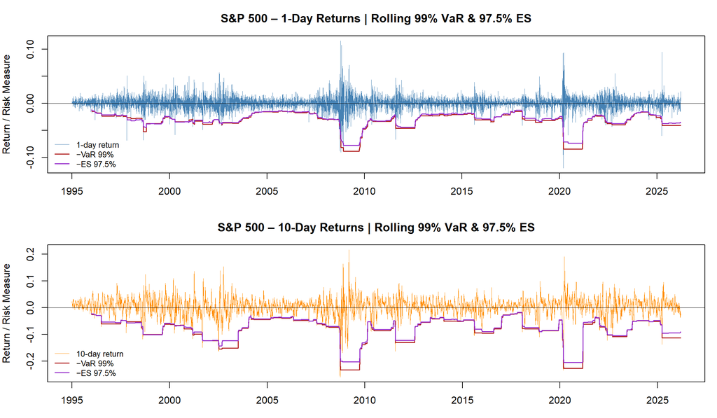

```r
# ── STEP 2 – Plot: Returns + VaR + ES together ───────────────────────────────
par(mfrow = c(2, 1), mar = c(3, 4, 3, 1))

# ── Panel 1 : 1-day ──────────────────────────────────────────────────────────
plot(dates_1d, returns_1d,
     type = "l", col = "steelblue", lwd = 0.6,
     main = "S&P 500 – 1-Day Returns | Rolling 99% VaR & 97.5% ES",
     xlab = "", ylab = "Return / Risk Measure", xaxt = "n",
     ylim = range(c(returns_1d, -VaR_1d, -ES_1d), na.rm = TRUE))
axis.Date(1, at = seq(min(dates_1d), max(dates_1d), by = "5 years"), format = "%Y")
lines(dates_1d, -VaR_1d, col = "firebrick",   lwd = 1.5)   # VaR as loss threshold
lines(dates_1d, -ES_1d,  col = "darkorchid",  lwd = 1.5)   # ES deeper in tail
abline(h = 0, col = "black", lwd = 0.5)
legend("bottomleft",
       legend = c("1-day return", "−VaR 99%", "−ES 97.5%"),
       col    = c("steelblue", "firebrick", "darkorchid"),
       lwd    = c(0.6, 1.5, 1.5), bty = "n", cex = 0.8)

# ── Panel 2 : 10-day ─────────────────────────────────────────────────────────
plot(dates_10d, returns_10d,
     type = "l", col = "darkorange", lwd = 0.6,
     main = "S&P 500 – 10-Day Returns | Rolling 99% VaR & 97.5% ES",
     xlab = "", ylab = "Return / Risk Measure", xaxt = "n",
     ylim = range(c(returns_10d, -VaR_10d, -ES_10d), na.rm = TRUE))
axis.Date(1, at = seq(min(dates_10d), max(dates_10d), by = "5 years"), format = "%Y")
lines(dates_10d, -VaR_10d, col = "firebrick",  lwd = 1.5)
lines(dates_10d, -ES_10d,  col = "darkorchid", lwd = 1.5)
abline(h = 0, col = "black", lwd = 0.5)
legend("bottomleft",
       legend = c("10-day return", "−VaR 99%", "−ES 97.5%"),
       col    = c("darkorange", "firebrick", "darkorchid"),
       lwd    = c(0.6, 1.5, 1.5), bty = "n", cex = 0.8)
```

```r
par(mfrow = c(1, 1))
```

## 5.5 ES Breach Analysis

```r
# ── STEP 3 – ES breach analysis ───────────────────────────────────────────────
#   An ES "breach" = actual loss exceeded even the ES estimate
breaches_ES_1d  <- sum(-returns_1d  > ES_1d,  na.rm = TRUE)
breaches_ES_10d <- sum(-returns_10d > ES_10d, na.rm = TRUE)

total_1d_es  <- sum(!is.na(ES_1d))
total_10d_es <- sum(!is.na(ES_10d))

cat("\n=== ES Breach Analysis ===\n")
```

```
##
## === ES Breach Analysis ===
```

```r
cat(sprintf("1-Day  ES breaches: %d / %d  (%.2f%%)\n",
            breaches_ES_1d,  total_1d_es,  100 * breaches_ES_1d  / total_1d_es))
```

```
## 1-Day  ES breaches: 110 / 7604  (1.45%)
```

```r
cat(sprintf("10-Day ES breaches: %d / %d  (%.2f%%)\n",
            breaches_ES_10d, total_10d_es, 100 * breaches_ES_10d / total_10d_es))
```

```
## 10-Day ES breaches: 150 / 7595  (1.97%)
```

## 5.6 VaR vs. ES — Summary Comparison

```r
# ── STEP 4 – Side-by-side comparison table: VaR vs ES peaks ──────────────────
cat("\n=== VaR vs ES – Key Comparison ===\n")
```

```
##
## === VaR vs ES – Key Comparison ===
```

```r
cat(sprintf("%-25s %10s %10s\n", "Metric", "1-Day", "10-Day"))
```

```
## Metric                         1-Day     10-Day
```

```r
cat(strrep("-", 47), "\n")
cat(sprintf("%-25s %10.4f %10.4f\n", "VaR 99% – Mean",    mean(VaR_1d,  na.rm=TRUE), mean(VaR_10d,  na.rm=TRUE)))
```

```
## VaR 99% – Mean              0.0322     0.0840
```

```r
cat(sprintf("%-25s %10.4f %10.4f\n", "VaR 99% – Max",     max(VaR_1d,   na.rm=TRUE), max(VaR_10d,   na.rm=TRUE)))
```

```
## VaR 99% – Max               0.0886     0.2319
```

```r
cat(sprintf("%-25s %10.4f %10.4f\n", "ES 97.5% – Mean",   mean(ES_1d,   na.rm=TRUE), mean(ES_10d,   na.rm=TRUE)))
```

```
## ES 97.5% – Mean             0.0302     0.0782
```

```r
cat(sprintf("%-25s %10.4f %10.4f\n", "ES 97.5% – Max",    max(ES_1d,    na.rm=TRUE), max(ES_10d,    na.rm=TRUE)))
```

```
## ES 97.5% – Max              0.0779     0.2047
```

```r
cat(sprintf("%-25s %10.4f %10.4f\n", "ES/VaR ratio (avg)",
            mean(ES_1d / VaR_1d, na.rm=TRUE),
            mean(ES_10d / VaR_10d, na.rm=TRUE)))
```

```
## ES/VaR ratio (avg)            0.9461     0.9439
```

# 6 IMA Charge — FRTB / Basel III

## 6.1 Methodology

Under the **Internal Models Approach (IMA)** of FRTB (Basel III), the capital charge is:

$$\text{IMA Charge} =
\max\left(\text{ES}_{\text{stress}},\
\text{ES}_{\text{recent}}\right)$$

| Component | Description |
| --- | --- |
| **Stress ES** | ES computed over the single worst 252-day window in the full history |
| **Recent ES** | ES computed over the most recent 252 trading days |
| **IMA Charge** | The binding (higher) of the two — ensures capital never falls below the stressed level |

## 6.2 Helper: Single-Window ES

```r
window <- 252
conf   <- 0.975
p      <- 1 - conf         # 0.025
tail_n     <- window * p   # 6.3
tail_full  <- floor(tail_n)    # 6
tail_frac  <- tail_n - tail_full   # 0.3

# ── Helper function ─────────────────────────────────────────────────────────
es_single_window <- function(ret_window) {
  sorted   <- sort(ret_window)          # ascending: worst first
  tail_sum <- sum(sorted[1:tail_full]) + tail_frac * sorted[tail_full + 1]
  return(-tail_sum / tail_n)            # positive loss number
}
```

## 6.3 Stress Period Identification

```r
# ── STEP 1 – Scan every possible 252-day window → find the STRESS PERIOD ─────
find_stress_period <- function(returns_vec, dates_vec, window = 252) {

  n          <- length(returns_vec)
  n_windows  <- n - window + 1
  es_all     <- numeric(n_windows)

  for (i in seq_len(n_windows)) {
    es_all[i] <- es_single_window(returns_vec[i:(i + window - 1)])
  }

  best_i          <- which.max(es_all)          # window with highest ES
  stress_es_value <- es_all[best_i]
  stress_start    <- dates_vec[best_i]
  stress_end      <- dates_vec[best_i + window - 1]

  return(list(
    stress_ES    = stress_es_value,
    stress_start = stress_start,
    stress_end   = stress_end,
    stress_index = best_i,
    all_es       = es_all
  ))
}

cat("Scanning all 252-day windows for 1-day returns...\n")
```

```
## Scanning all 252-day windows for 1-day returns...
```

```r
stress_1d  <- find_stress_period(returns_1d,  dates_1d)

cat("Scanning all 252-day windows for 10-day returns...\n")
```

```
## Scanning all 252-day windows for 10-day returns...
```

```r
stress_10d <- find_stress_period(returns_10d, dates_10d)

cat("\n=== Stress Period – 1-Day Returns ===\n")
```

```
##
## === Stress Period – 1-Day Returns ===
```

```r
cat(sprintf("  Period : %s  to  %s\n",
            format(stress_1d$stress_start), format(stress_1d$stress_end)))
```

```
##   Period : 2007-12-03  to  2008-12-01
```

```r
cat(sprintf("  Stress ES (97.5%%) : %.4f  (%.2f%%)\n",
            stress_1d$stress_ES, stress_1d$stress_ES * 100))
```

```
##   Stress ES (97.5%) : 0.0779  (7.79%)
```

```r
cat("\n=== Stress Period – 10-Day Returns ===\n")
```

```
##
## === Stress Period – 10-Day Returns ===
```

```r
cat(sprintf("  Period : %s  to  %s\n",
            format(stress_10d$stress_start), format(stress_10d$stress_end)))
```

```
##   Period : 2019-03-25  to  2020-03-23
```

```r
cat(sprintf("  Stress ES (97.5%%) : %.4f  (%.2f%%)\n",
            stress_10d$stress_ES, stress_10d$stress_ES * 100))
```

```
##   Stress ES (97.5%) : 0.2047  (20.47%)
```

## 6.4 Recent ES

```r
# ── STEP 2 – Recent ES  (last 252 observations = most recent rolling window) ──
recent_ES_1d  <- es_single_window(tail(returns_1d,  window))
recent_ES_10d <- es_single_window(tail(returns_10d, window))

cat("\n=== Recent ES (97.5%%) – last 252 days ===\n")
```

```
##
## === Recent ES (97.5%%) – last 252 days ===
```

```r
cat(sprintf("  1-Day  Recent ES : %.4f  (%.2f%%)\n",
            recent_ES_1d,  recent_ES_1d  * 100))
```

```
##   1-Day  Recent ES : 0.0352  (3.52%)
```

```r
cat(sprintf("  10-Day Recent ES : %.4f  (%.2f%%)\n",
            recent_ES_10d, recent_ES_10d * 100))
```

```
##   10-Day Recent ES : 0.0904  (9.04%)
```

## 6.5 IMA Capital Charge

```r
# ── STEP 3 – IMA Charge  =  max(Stress ES, Recent ES) ────────────────────────
IMA_1d  <- max(stress_1d$stress_ES,  recent_ES_1d)
IMA_10d <- max(stress_10d$stress_ES, recent_ES_10d)

cat("\n")
```

```r
cat(sprintf("  %-30s %10s %10s\n", "Metric", "1-Day", "10-Day"))
```

```
##   Metric                              1-Day     10-Day
```

```r
cat(strrep("─", 55), "\n")
cat(sprintf("  %-30s %10.4f %10.4f\n", "Stress ES (97.5%)",
            stress_1d$stress_ES,  stress_10d$stress_ES))
```

```
##   Stress ES (97.5%)                  0.0779     0.2047
```

```r
cat(sprintf("  %-30s %10.4f %10.4f\n", "Recent ES (97.5%)",
            recent_ES_1d,         recent_ES_10d))
```

```
##   Recent ES (97.5%)                  0.0352     0.0904
```

```r
cat(strrep("─", 55), "\n")
cat(sprintf("  %-30s %10.4f %10.4f\n", "IMA Charge  [max of above]",
            IMA_1d, IMA_10d))
```

```
##   IMA Charge  [max of above]         0.0779     0.2047
```

```r
cat(sprintf("  %-30s %10s %10s\n", "Binding constraint",
            ifelse(stress_1d$stress_ES  >= recent_ES_1d,  "STRESS", "RECENT"),
            ifelse(stress_10d$stress_ES >= recent_ES_10d, "STRESS", "RECENT")))
```

```
##   Binding constraint                 STRESS     STRESS
```

```r
cat(strrep("═", 55), "\n")
```

```
## ═══════════════════════════════════════════════════════
```

## 6.6 Stress Period Visualisation

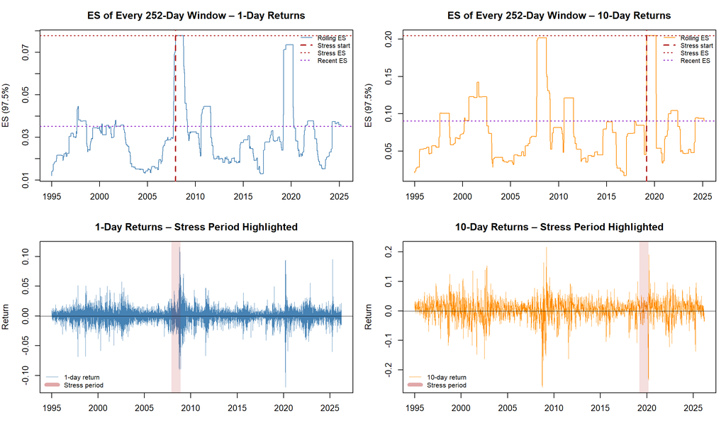

```r
# ── STEP 4 – Visualisation ────────────────────────────────────────────────────
par(mfrow = c(2, 2), mar = c(3, 4, 3, 1))

# Dates aligned to the scanning windows
dates_scan_1d  <- dates_1d [1:(length(returns_1d)  - window + 1)]
dates_scan_10d <- dates_10d[1:(length(returns_10d) - window + 1)]

# ── Panel 1 : ES of every window – 1-day ─────────────────────────────────────
plot(dates_scan_1d, stress_1d$all_es,
     type = "l", col = "steelblue", lwd = 1,
     main = "ES of Every 252-Day Window – 1-Day Returns",
     xlab = "", ylab = "ES (97.5%)", xaxt = "n")
axis.Date(1, at = seq(min(dates_scan_1d), max(dates_scan_1d), by = "5 years"),
          format = "%Y")
abline(v   = stress_1d$stress_start, col = "firebrick", lwd = 2, lty = 2)
abline(h   = stress_1d$stress_ES,    col = "firebrick", lwd = 1.5, lty = 3)
abline(h   = recent_ES_1d,           col = "darkorchid", lwd = 1.5, lty = 3)
legend("topright",
       legend = c("Rolling ES", "Stress start", "Stress ES", "Recent ES"),
       col    = c("steelblue","firebrick","firebrick","darkorchid"),
       lwd    = c(1, 2, 1.5, 1.5),
       lty    = c(1, 2, 3, 3), bty = "n", cex = 0.75)

# ── Panel 2 : ES of every window – 10-day ────────────────────────────────────
plot(dates_scan_10d, stress_10d$all_es,
     type = "l", col = "darkorange", lwd = 1,
     main = "ES of Every 252-Day Window – 10-Day Returns",
     xlab = "", ylab = "ES (97.5%)", xaxt = "n")
axis.Date(1, at = seq(min(dates_scan_10d), max(dates_scan_10d), by = "5 years"),
          format = "%Y")
abline(v = stress_10d$stress_start, col = "firebrick", lwd = 2, lty = 2)
abline(h = stress_10d$stress_ES,    col = "firebrick", lwd = 1.5, lty = 3)
abline(h = recent_ES_10d,           col = "darkorchid", lwd = 1.5, lty = 3)
legend("topright",
       legend = c("Rolling ES", "Stress start", "Stress ES", "Recent ES"),
       col    = c("darkorange","firebrick","firebrick","darkorchid"),
       lwd    = c(1, 2, 1.5, 1.5),
       lty    = c(1, 2, 3, 3), bty = "n", cex = 0.75)

# ── Panel 3 : 1-day returns shaded over stress period ────────────────────────
plot(dates_1d, returns_1d,
     type = "l", col = "steelblue", lwd = 0.6,
     main = "1-Day Returns – Stress Period Highlighted",
     xlab = "", ylab = "Return", xaxt = "n")
axis.Date(1, at = seq(min(dates_1d), max(dates_1d), by = "5 years"), format = "%Y")
rect(stress_1d$stress_start, par("usr")[3],
     stress_1d$stress_end,   par("usr")[4],
     col = adjustcolor("firebrick", alpha.f = 0.15), border = NA)
abline(h = 0, lwd = 0.5)
legend("bottomleft",
       legend = c("1-day return", "Stress period"),
       col    = c("steelblue", adjustcolor("firebrick", 0.4)),
       lwd    = c(0.6, 6), bty = "n", cex = 0.8)

# ── Panel 4 : 10-day returns shaded over stress period ───────────────────────
plot(dates_10d, returns_10d,
     type = "l", col = "darkorange", lwd = 0.6,
     main = "10-Day Returns – Stress Period Highlighted",
     xlab = "", ylab = "Return", xaxt = "n")
axis.Date(1, at = seq(min(dates_10d), max(dates_10d), by = "5 years"), format = "%Y")
rect(stress_10d$stress_start, par("usr")[3],
     stress_10d$stress_end,   par("usr")[4],
     col = adjustcolor("firebrick", alpha.f = 0.15), border = NA)
abline(h = 0, lwd = 0.5)
legend("bottomleft",
       legend = c("10-day return", "Stress period"),
       col    = c("darkorange", adjustcolor("firebrick", 0.4)),
       lwd    = c(0.6, 6), bty = "n", cex = 0.8)
```

```r
par(mfrow = c(1, 1))
```

# 7 Basel Backtesting — Traffic Light Approach

## 7.1 Regime-Based Synthetic Return Series

A regime-switching model is used to generate a synthetic S&P 500-like daily return series from 2007 to present, capturing three distinct volatility environments:

| Regime | Period | Mean (daily) | Vol (daily) |
| --- | --- | --- | --- |
| Normal market | All other periods | +0.03% | 1.0% |
| Crisis | GFC 2008–09, COVID 2020 | −0.08 to −0.15% | 2.5–2.8% |
| Elevated vol | 2011, 2018, 2022 | 0.00% | 1.6% |

```r
set.seed(42)

# ── STEP 1 – Generate dummy S&P 500-like daily returns (2007 to present) ──────
#
#   Regime model:
#   • Normal market  : mean = +0.03%, vol = 1.0%
#   • Crisis period  : mean = -0.15%, vol = 2.8%  (2008–2009, 2020 COVID)
#   • Elevated vol   : mean =  0.00%, vol = 1.6%  (2011, 2018, 2022)
dates_bt <- seq(as.Date("2007-01-02"), Sys.Date(), by = "day")
dates_bt <- dates_bt[!weekdays(dates_bt) %in% c("Saturday", "Sunday")]
n_days   <- length(dates_bt)

set.seed(42)
returns_bt <- numeric(n_days)

for (i in seq_len(n_days)) {
  d <- dates_bt[i]

  # Crisis regimes
  if (d >= as.Date("2008-09-01") & d <= as.Date("2009-06-30")) {
    returns_bt[i] <- rnorm(1, mean = -0.0015, sd = 0.028)   # GFC
  } else if (d >= as.Date("2020-02-20") & d <= as.Date("2020-05-31")) {
    returns_bt[i] <- rnorm(1, mean = -0.0008, sd = 0.025)   # COVID crash
  } else if ((d >= as.Date("2011-07-01") & d <= as.Date("2011-12-31")) |
             (d >= as.Date("2018-10-01") & d <= as.Date("2018-12-31")) |
             (d >= as.Date("2022-01-01") & d <= as.Date("2022-12-31"))) {
    returns_bt[i] <- rnorm(1, mean = 0.0000, sd = 0.016)    # elevated vol
  } else {
    returns_bt[i] <- rnorm(1, mean = 0.0003, sd = 0.010)    # normal
  }
}

cat(sprintf("Dummy dataset: %d trading days | %s to %s\n",
            n_days, format(min(dates_bt)), format(max(dates_bt))))
```

```
## Dummy dataset: 7026 trading days | 2007-01-02 to 2026-03-28
```

## 7.2 Rolling 99% VaR — Forward-Shifted

The VaR estimate for day $t$ is computed from the **prior 252 trading days** $[t{-}252,\ t{-}1]$.  
This one-day forward shift ensures the prediction is strictly **out-of-sample**.

```r
# ── STEP 2 – Rolling 99% VaR with 252-day lookback ───────────────────────────
#             SHIFTED by 1 day so VaR[t] = prediction for day t
#             (estimated from days t-252 to t-1)
window_bt <- 252
conf_bt   <- 0.99
p_bt      <- 1 - conf_bt                # 0.01

# Interpolation parameters: h = 253 × 0.01 = 2.53
h_bt      <- (window_bt + 1) * p_bt    # 2.53
lo_bt     <- floor(h_bt)               # 2
hi_bt     <- lo_bt + 1                 # 3
frac_bt   <- h_bt - lo_bt              # 0.53

VaR_bt    <- rep(NA_real_, n_days)

for (t in (window_bt + 1):n_days) {
  # Use days [t-252 : t-1]  →  prediction for day t  (the SHIFT)
  past    <- returns_bt[(t - window_bt):(t - 1)]
  sorted  <- sort(past)
  VaR_bt[t] <- -(sorted[lo_bt] + frac_bt * (sorted[hi_bt] - sorted[lo_bt]))
}

cat(sprintf("\nVaR estimation active from: %s\n",
            format(dates_bt[window_bt + 1])))
```

```
##
## VaR estimation active from: 2007-09-11
```

## 7.3 Exception Identification

```r
# ── STEP 3 – Identify exceptions (breaches) ──────────────────────────────────
#             Breach when:  actual LOSS  >  predicted VaR
#             i.e.          -return_t    >  VaR_t
# loss = -return  (positive number = money lost)
loss_bt    <- -returns_bt
breach_bt  <- (!is.na(VaR_bt)) & (loss_bt > VaR_bt)

breach_dates  <- dates_bt[breach_bt]
breach_losses <- loss_bt[breach_bt]
breach_VaRs   <- VaR_bt[breach_bt]

cat(sprintf("\nTotal breaches (full history): %d\n", sum(breach_bt, na.rm = TRUE)))
```

```
##
## Total breaches (full history): 85
```

```r
cat(sprintf("Overall breach rate         : %.2f%% (expected ~1%%)\n",
            100 * mean(breach_bt, na.rm = TRUE)))
```

```
## Overall breach rate         : 1.21% (expected ~1%)
```

## 7.4 Basel Traffic Light Classification

The **Basel III Traffic Light** evaluates model performance over the **most recent 250 trading days**:

| Zone | Breaches | Capital add-on ($\Delta k$) |
| --- | --- | --- |
| 🟢 **Green** | 0 – 4 | 0.00 |
| 🟡 **Amber** | 5 – 9 | 0.40 – 0.85 |
| 🔴 **Red** | ≥ 10 | 1.00 |

```r
# ── STEP 4 – Basel Traffic Light: count breaches in MOST RECENT 250-day window ─
tl_window    <- 250

# Most recent 250 days where VaR was already available
valid_idx    <- which(!is.na(VaR_bt))
recent_idx   <- tail(valid_idx, tl_window)
recent_dates <- dates_bt[recent_idx]

recent_breaches  <- sum(breach_bt[recent_idx])
recent_breach_pct <- 100 * recent_breaches / tl_window

# Traffic Light classification
tl_status <- dplyr::case_when(
  recent_breaches <= 4  ~ "GREEN",
  recent_breaches <= 9  ~ "AMBER",
  TRUE                  ~ "RED"
)

# Multiplier table (Basel III, Table – Addition to k)
multiplier_table <- data.frame(
  zone     = c("GREEN","GREEN","GREEN","GREEN","GREEN",
               "AMBER","AMBER","AMBER","AMBER","AMBER","RED"),
  breaches = 0:10,
  addition = c(0.00, 0.00, 0.00, 0.00, 0.00,
               0.40, 0.50, 0.65, 0.75, 0.85, 1.00)
)

k_addition <- multiplier_table$addition[multiplier_table$breaches ==
                                          min(recent_breaches, 10)]

cat("\n")
```

```r
cat(strrep("═", 55), "\n")
```

```
## ═══════════════════════════════════════════════════════
```

```r
cat(sprintf("  %-35s %s\n", "Recent 250-day window start:", format(min(recent_dates))))
```

```
##   Recent 250-day window start:        2025-07-22
```

```r
cat(sprintf("  %-35s %s\n", "Recent 250-day window end:",   format(max(recent_dates))))
```

```
##   Recent 250-day window end:          2026-03-28
```

```r
cat(strrep("─", 55), "\n")
cat(sprintf("  %-35s %d\n",    "Breaches in last 250 days:", recent_breaches))
```

```
##   Breaches in last 250 days:          5
```

```r
cat(sprintf("  %-35s %.2f%%\n","Breach rate:",                recent_breach_pct))
```

```
##   Breach rate:                        2.00%
```

```r
cat(sprintf("  %-35s +%.2f\n", "Basel k multiplier addition:", k_addition))
```

```
##   Basel k multiplier addition:        +0.40
```

```r
cat(strrep("─", 55), "\n")
cat(sprintf("  TRAFFIC LIGHT STATUS:  [ %s ]\n", tl_status))
```

```
##   TRAFFIC LIGHT STATUS:  [ AMBER ]
```

```r
cat(strrep("═", 55), "\n")
```

```
## ═══════════════════════════════════════════════════════
```

## 7.5 Backtesting Chart

[figure not shown]

```r
# ── STEP 5 – Plot ─────────────────────────────────────────────────────────────
valid        <- !is.na(VaR_bt)
plot_dates   <- dates_bt[valid]
plot_returns <- returns_bt[valid]
plot_VaR     <- VaR_bt[valid]
plot_breaches <- breach_bt[valid]

plot(plot_dates, plot_returns,
     type = "l", col = "steelblue", lwd = 0.6,
     main = sprintf("S&P 500 – Daily Returns vs. Rolling 99%% VaR | Backtesting"),
     xlab = "Date", ylab = "Daily Return",
     ylim = range(c(plot_returns, -plot_VaR), na.rm = TRUE),
     xaxt = "n")
axis.Date(1, at = seq(min(plot_dates), max(plot_dates), by = "2 years"),
          format = "%Y")

# VaR threshold (shown as negative = loss side)
lines(plot_dates, -plot_VaR, col = "firebrick", lwd = 1.8)

# Highlight breach points
points(plot_dates[plot_breaches],
       plot_returns[plot_breaches],
       col = "red", pch = 19, cex = 0.9)

# Shade the most recent 250-day window
rect(min(recent_dates), par("usr")[3],
     max(recent_dates), par("usr")[4],
     col = adjustcolor("gold", alpha.f = 0.12), border = NA)

# Traffic light colour box
tl_col <- switch(tl_status, GREEN = "#2ecc71", AMBER = "#f39c12", RED = "#e74c3c")
legend("bottomleft",
       legend = c("Daily return", "−VaR 99%",
                  "Breach",
                  sprintf("250-day window  (%s: %d breaches)",
                          tl_status, recent_breaches)),
       col    = c("steelblue", "firebrick", "red", adjustcolor("gold", 0.5)),
       pch    = c(NA, NA, 19, 15),
       lwd    = c(0.6, 1.8, NA, NA),
       pt.cex = c(NA, NA, 0.9, 1.5),
       bty    = "n", cex = 0.75,
       text.col = c(rep("black", 3), tl_col))

abline(h = 0, col = "black", lwd = 0.4)
```

# 8 Summary

[output not shown]